# Part II - (Prosper Loan Data Presentation)

## by (Innocent Mukoki)

## Investigation Overview

> In this investigation, I wanted to find out the factors that affect the original loan amount. The features in the dataset which helped support my investigation into the original loan amount are income range, loan status, monthly income, income verifiable, months since origination, origination quarter, origination date, is borrower homeowner, term, borrow rate, listing category and monthly loan payment.

> The insights that were obtained from this investigation is that generally the number of loans issued decrease as the original loan amount increases with some peaks happening in-between. It was also observed that only original loan amount and monthly loan payment have a strong relationship, the rest of the features have a weak relationship. Generally there is an increase in the average original loan amount as the years progress. It was observed that the scatter plot of original loan amount against monthly loan payment was split into 3 sections using the terms and that each section had a linear relationship. The slope of the linear relationship increased as the term became long which means that as the term becomes longer, the borrower pays less money per month. It was observed that the average original loan amount increases as the term becomes longer. The general trend shows that the average original amount increases as the the time progresses for the 12 and 36 month terms whilst it first decreases then increases for the 60 month term.

## Dataset Overview

> There are 113,937 loans in the dataset with 81 variables. Most variables are numeric in nature. The dataset can be found [here](https://s3.amazonaws.com/udacity-hosted-downloads/ud651/prosperLoanData.csv) and the feature documentation can be found [here](https://docs.google.com/spreadsheets/d/1gDyi_L4UvIrLTEC6Wri5nbaMmkGmLQBk-Yx3z0XDEtI/edit#gid=0)

## Distribution of original loan amount

> Original loan amount is the money that was borrowed by the borrower. Generally the number of loans issued decrease as the original loan amount increases with some peaks happening in-between.

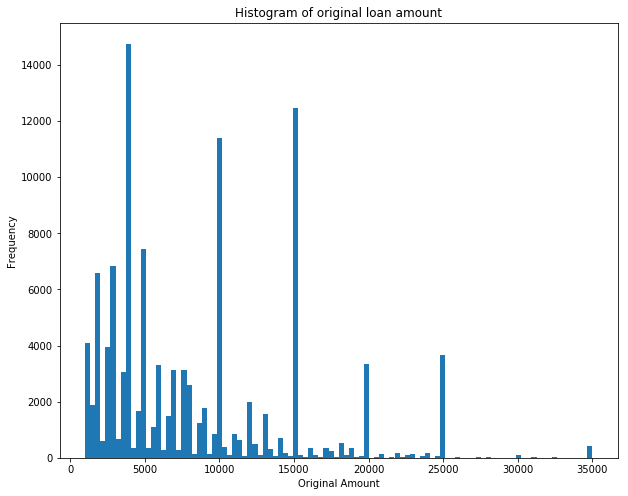

## Relationship between the features

> Correlation between the features was computed and used to come up with a heatmap. It can be seen that only original loan amount and monthly loan payment have a strong relationship. The rest of the features have a weak relationship.

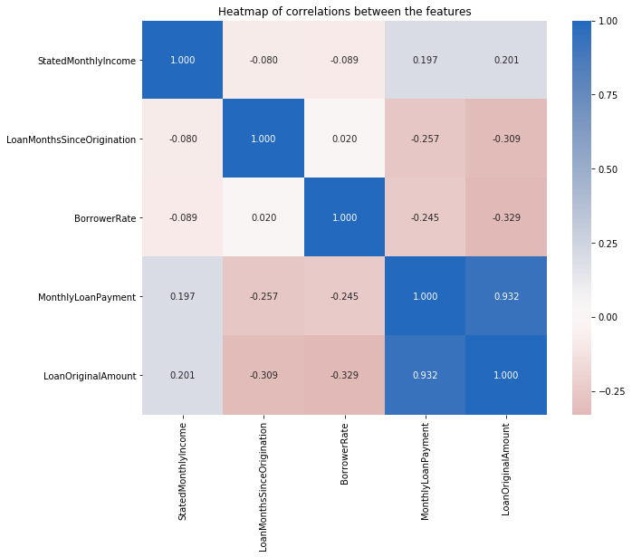

## General trend of average original loan amount

> The original loan amounts were averaged by year and a plot to show the trend was created. Generally there is an increase in the average original loan amount as the years progress.

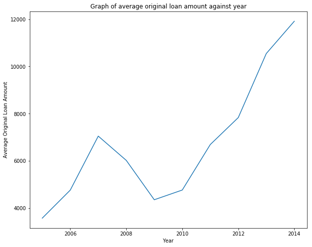

## Relationship between original loan amount, monthly loan payment and term

> Scatter plot of original loan amount against monthly loan payment was plotted and different colors were used to differentiate the terms. It was observed that the scatter plot was split into 3 sections using the terms and that each section had a linear relationship between original loan amount and monthly loan payment.

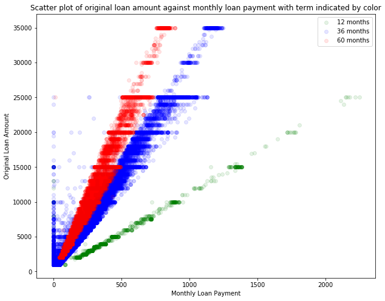

## General trend of average original loan amount separated by term

> A plot of average original loan amount against year was plotted and different colors were used to separate the terms. It can be seen that the average original loan amount increases as the term becomes longer. The general trend shows that the average original amount increases as the the time progresses for the 12 and 36 month terms whilst it first decreases then increases for the 60 month term.

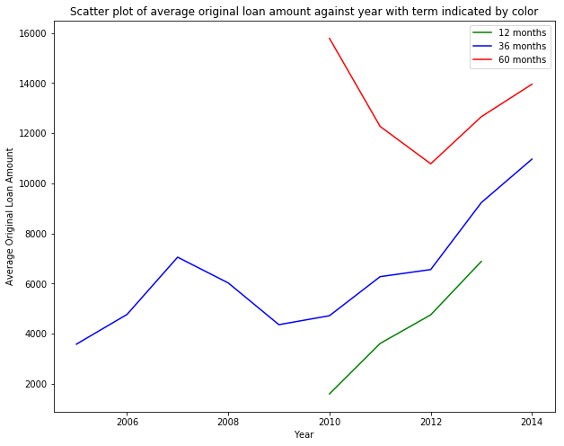